# N2234_4 exp

2023-07-19

More stringent clean-up of the raw datasets

```r
setwd("C:/Users/sandeh/OneDrive - Karolinska Institutet/Dokument/Generalprojectdocuments/Nodder 10x/July2023")
```

```r
library(Seurat)
```

```r
library(ggplot2)
library(sctransform)
library(scDblFinder)
library(SingleCellExperiment)
```

```r
N2234_4_data <- Read10X_h5("2234_4_filtered_feature_bc_matrix.h5")
N2234_4 <- CreateSeuratObject(counts = N2234_4_data)
N2234_4
```

```
## An object of class Seurat
## 32286 features across 13836 samples within 1 assay
## Active assay: RNA (32286 features, 0 variable features)
```

```r
N2234_4[["percent.mt"]] <- PercentageFeatureSet(N2234_4, pattern = "^mt-")
```

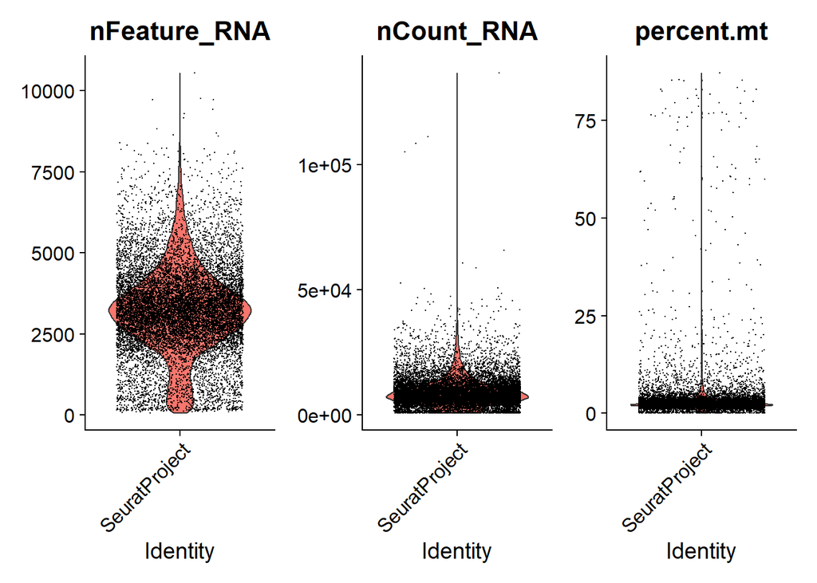

```r
VlnPlot(N2234_4, features = c("nFeature_RNA", "nCount_RNA", "percent.mt"), ncol = 3)
```

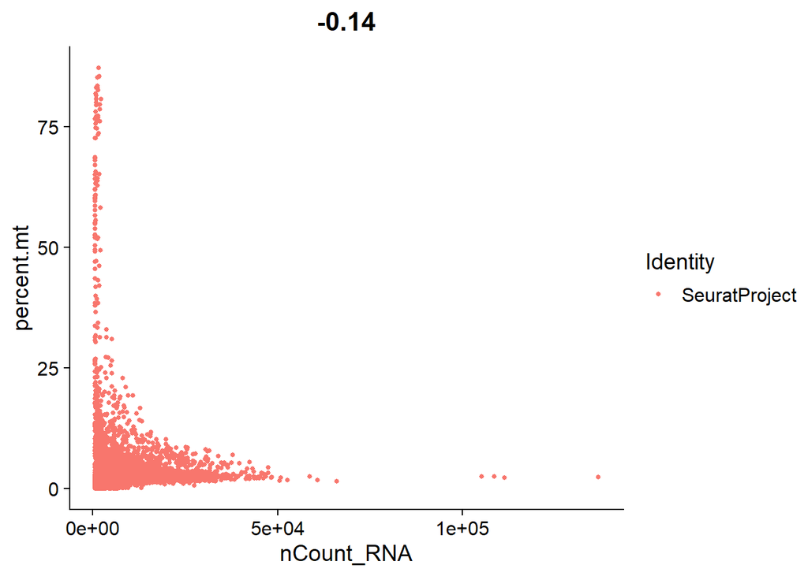

```r
FeatureScatter(N2234_4, feature1 = "nCount_RNA", feature2 = "percent.mt")
```

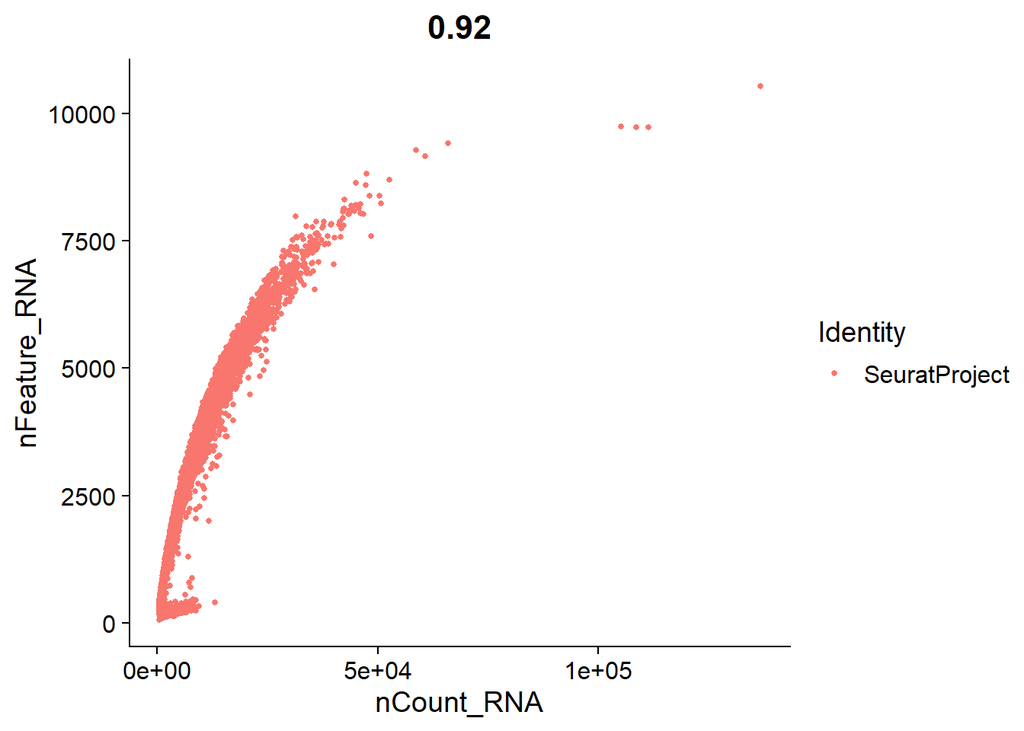

```r
FeatureScatter(N2234_4, feature1 = "nCount_RNA", feature2 = "nFeature_RNA")
```

Initial filtering

```r
N2234_4 <- subset(N2234_4, subset = nCount_RNA <50000 & nFeature_RNA > 2000 & percent.mt <20)
```

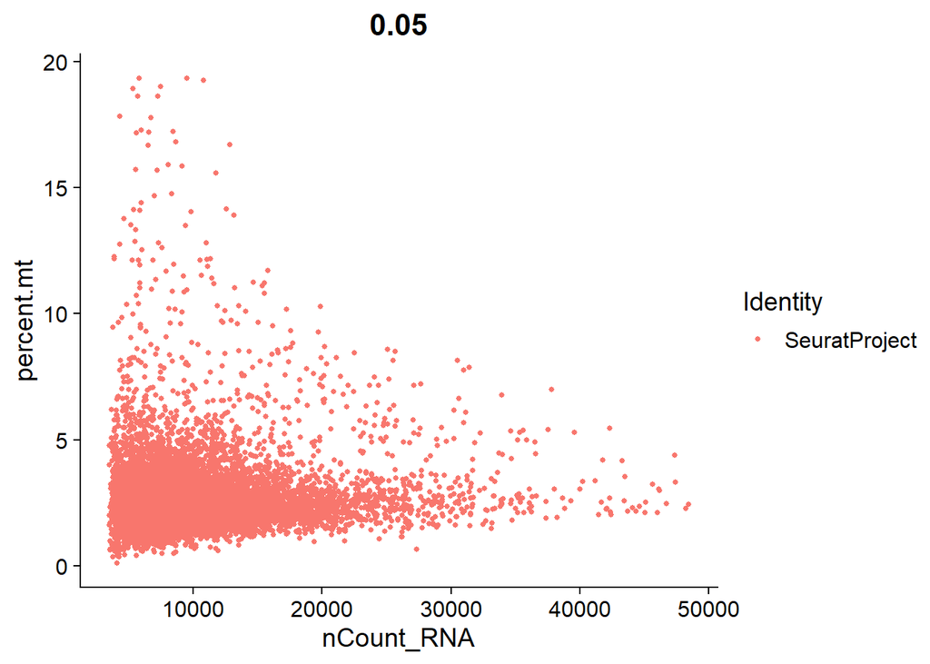

```r
FeatureScatter(N2234_4, feature1 = "nCount_RNA", feature2 = "percent.mt")
```

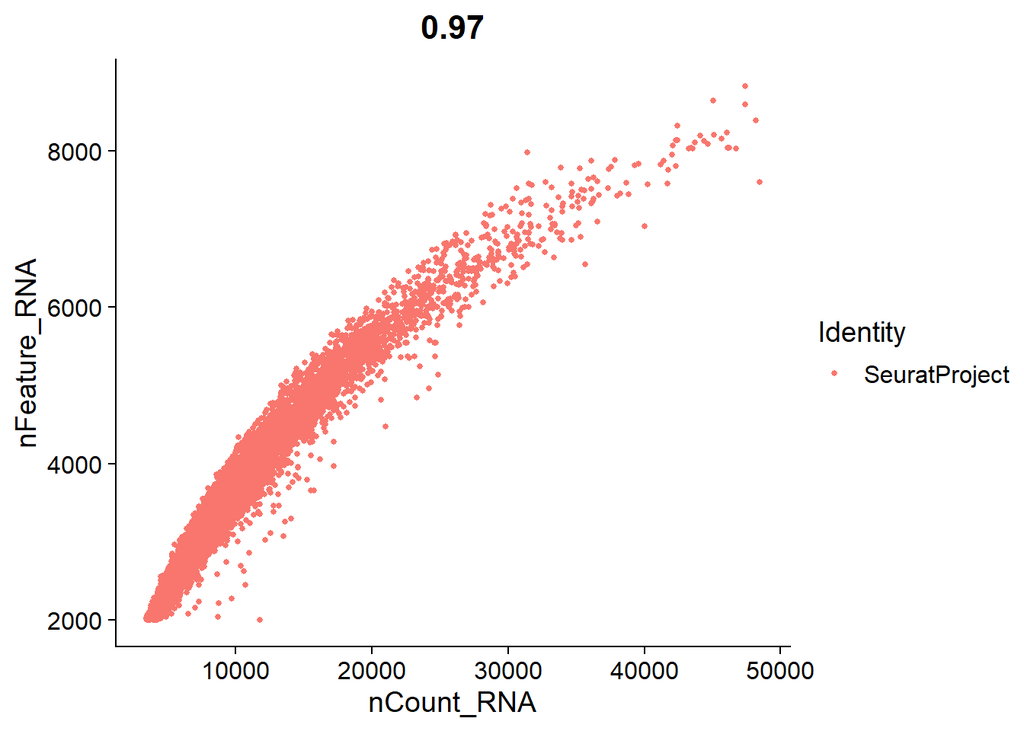

```r
FeatureScatter(N2234_4, feature1 = "nCount_RNA", feature2 = "nFeature_RNA")
```

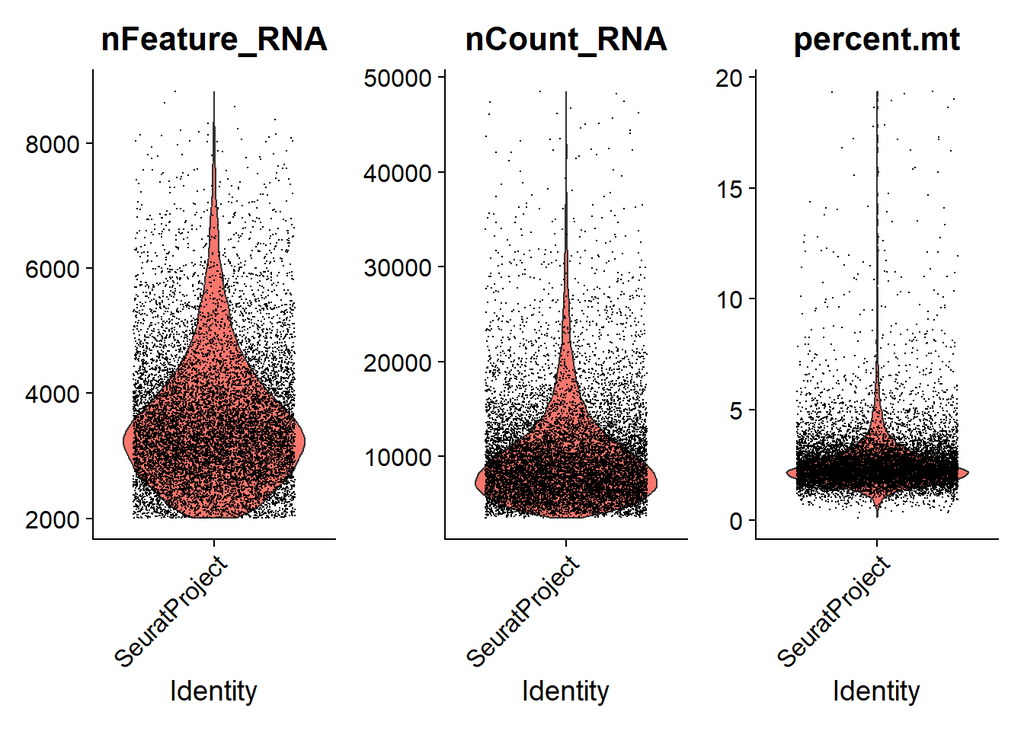

```r
VlnPlot(N2234_4, features = c("nFeature_RNA", "nCount_RNA", "percent.mt"), ncol = 3)
```

Lets go even lower to 10% percent.mt (also based on integrated datasets). To have the wildtype datasets as clean as possible.

```r
N2234_4 <- subset(N2234_4, subset = nCount_RNA <50000 & nFeature_RNA > 2000 &percent.mt <10)
```

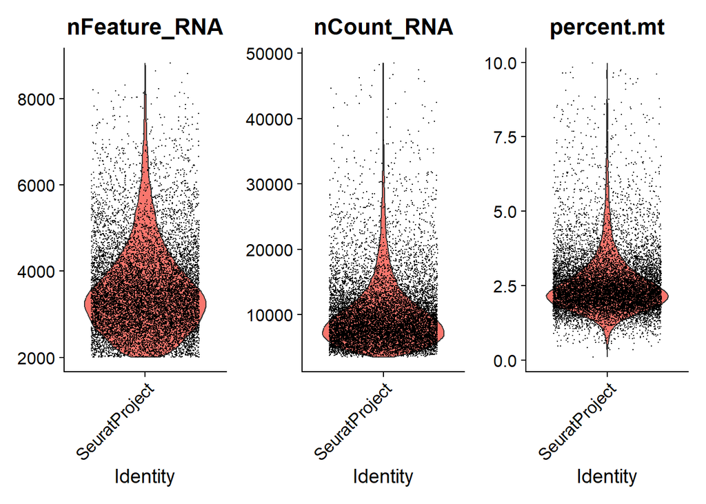

```r
VlnPlot(N2234_4, features = c("nFeature_RNA", "nCount_RNA", "percent.mt"), ncol = 3)
```

Lets normalise the data using SCTransform V2, with regression of percent.mt

```r
N2234_4 <- SCTransform(N2234_4, vst.flavor = "v2", vars.to.regress = "percent.mt")
```

```
## vst.flavor='v2' set, setting model to use fixed slope and exclude poisson genes.
```

```
## Calculating cell attributes from input UMI matrix: log_umi
```

```
## Total Step 1 genes: 20990
```

```
## Total overdispersed genes: 19170
```

```
## Excluding 1820 genes from Step 1 because they are not overdispersed.
```

```
## Variance stabilizing transformation of count matrix of size 22673 by 11802
```

```
## Model formula is y ~ log_umi
```

```
## Get Negative Binomial regression parameters per gene
```

```
## Using 2000 genes, 5000 cells
```

```
## Setting estimate of  163 genes to inf as theta_mm/theta_mle < 1e-3
```

```
## # of step1 poisson genes (variance < mean): 0
```

```
## # of low mean genes (mean < 0.001): 1761
```

```
## Total # of Step1 poisson genes (theta=Inf; variance < mean): 189
```

```
## Total # of poisson genes (theta=Inf; variance < mean): 3433
```

```
## Calling offset model for all 3433 poisson genes
```

```
## Found 183 outliers - those will be ignored in fitting/regularization step
```

```
## Ignoring theta inf genes
```

```
## Replacing fit params for 3433 poisson genes by theta=Inf
```

```
## Setting min_variance based on median UMI:  0.04
```

```
## Second step: Get residuals using fitted parameters for 22673 genes
```

```
## Computing corrected count matrix for 22673 genes
```

```
## Wall clock passed: Time difference of 1.72837 mins
```

```
## Determine variable features
```

```
## Place corrected count matrix in counts slot
```

```
## Centering data matrix
```

```
## Set default assay to SCT
```

```r
N2234_4 <- RunPCA(N2234_4, verbose = FALSE)
```

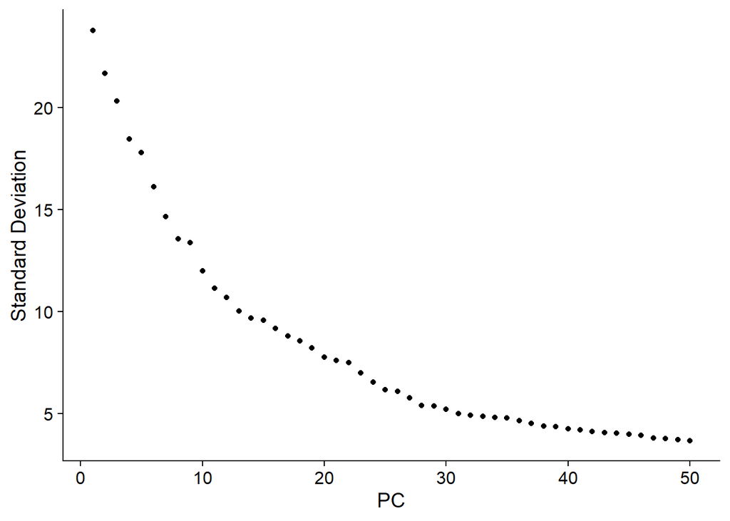

```r
ElbowPlot(N2234_4, ndims = 50)
```

Before I overclustered the datasets a bit, but for this initial filtering I am only interested in getting out the Epcam+ clusters, so I am not clustering at max settings, but at 30 for now

```r
N2234_4 <- FindNeighbors(N2234_4, dims = 1:30, verbose = FALSE)
N2234_4 <- FindClusters(N2234_4, verbose = FALSE)
N2234_4 <- RunUMAP(N2234_4, dims = 1:30, verbose = FALSE)
```

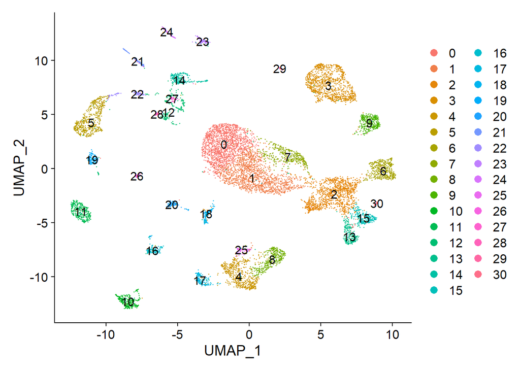

```r
DimPlot(N2234_4, label = TRUE)
```

```r
OCmarkers <- c("Epcam", "Sox2", "Myo7a", "Myo6", "Ccer2", "Otof", "Fgf8", "Ocm", "Pou4f3", "Fabp7", "S100a1", "Hey2", "Npy", "Mansc4", "Oc90")
```

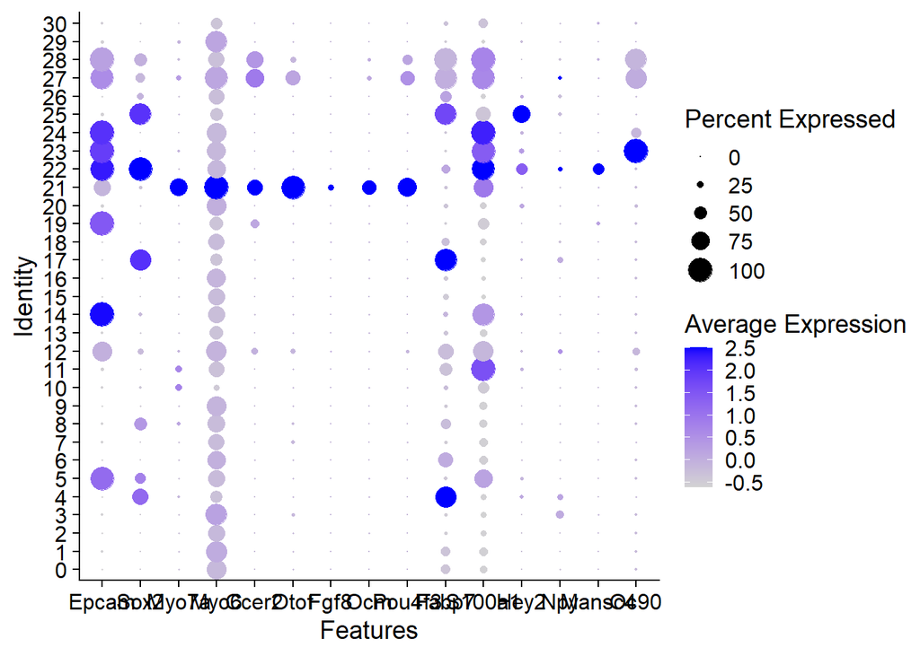

```r
DotPlot(N2234_4, features = OCmarkers)
```

```r
DefaultAssay(N2234_4) <- "SCT"
```

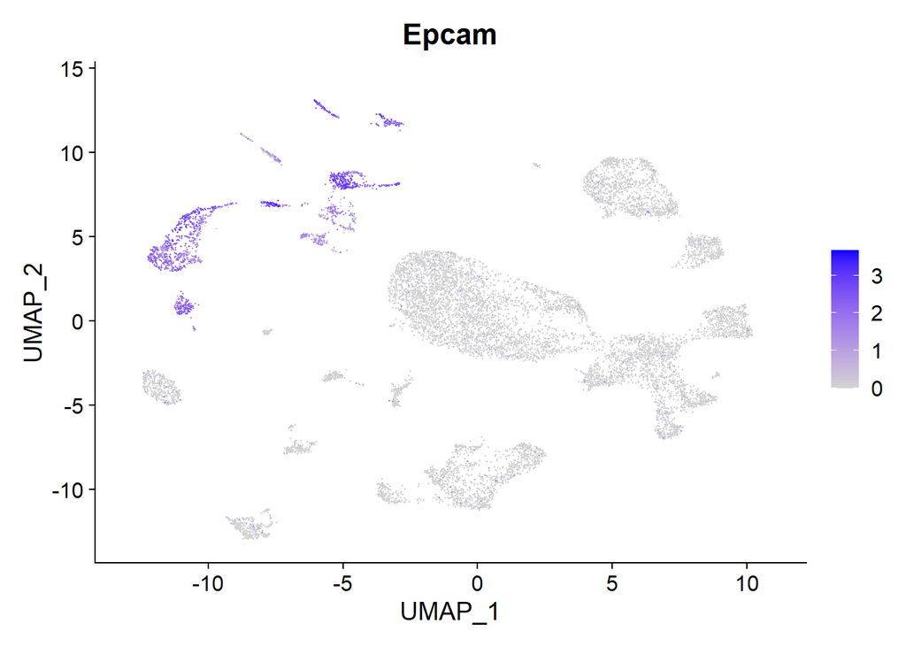

```r
FeaturePlot(N2234_4, features = c("Epcam"))
```

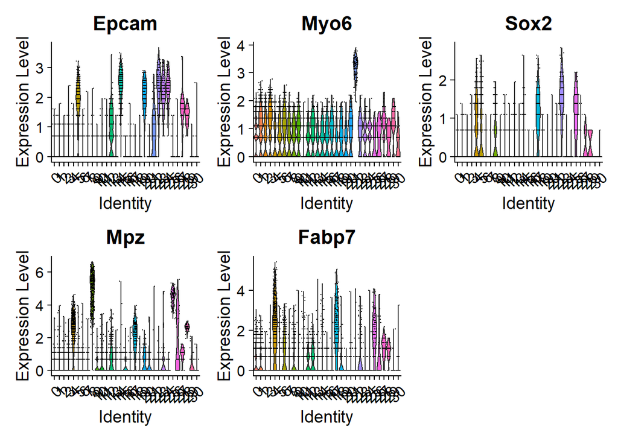

```r
VlnPlot(N2234_4, features = c("Epcam", "Myo6", "Sox2", "Mpz", "Fabp7"))
```

Clusters of interest are, Epcam and Myo6 (Sox2+, Epcam- clusters are glia, not including glia right now) : 5, 12, 14, 19, 21, 22, 23, 24, 27, 28

But first I will remove the doublets.

```r
sce <- as.SingleCellExperiment(N2234_4)
sce <- scDblFinder(sce)
```

```
## Creating ~9442 artificial doublets...
```

```
## Dimensional reduction
```

```
## Evaluating kNN...
```

```
## Training model...
```

```
## iter=0, 1344 cells excluded from training.
```

```
## iter=1, 858 cells excluded from training.
```

```
## iter=2, 824 cells excluded from training.
```

```
## Threshold found:0.046
```

```
## 639 (5.4%) doublets called
```

```r
sce_seurat <- as.Seurat(sce)
```

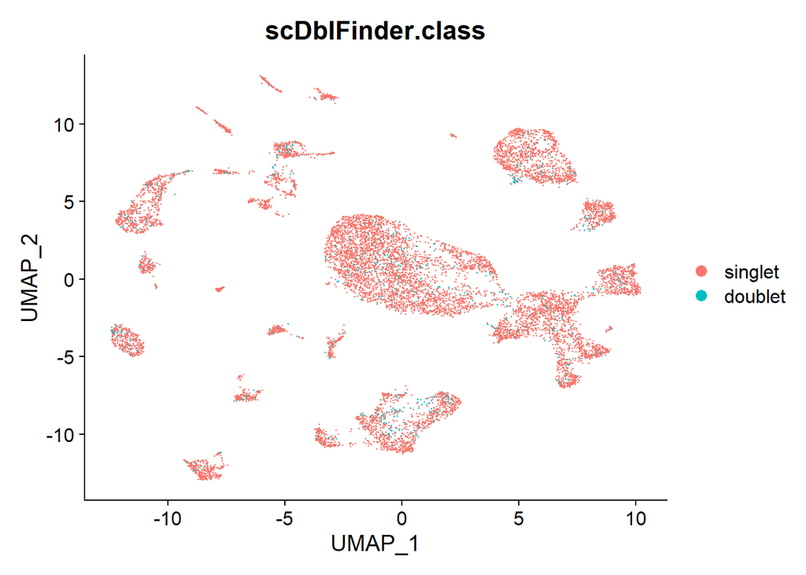

```r
DimPlot(sce_seurat, group.by = "scDblFinder.class")
```

```r
Idents(sce_seurat) <- "scDblFinder.class"
```

```r
N2234_4 <- subset(sce_seurat, scDblFinder.class == "singlet")
```

Lets subset to Epcam+ clusters as indicated above

```r
Idents(N2234_4) <- "seurat_clusters"
```

```r
N2234_4_QC <- subset(N2234_4, idents= c("5", "12", "14", "19", "21", "22", "23", "24", "27", "28"))
```

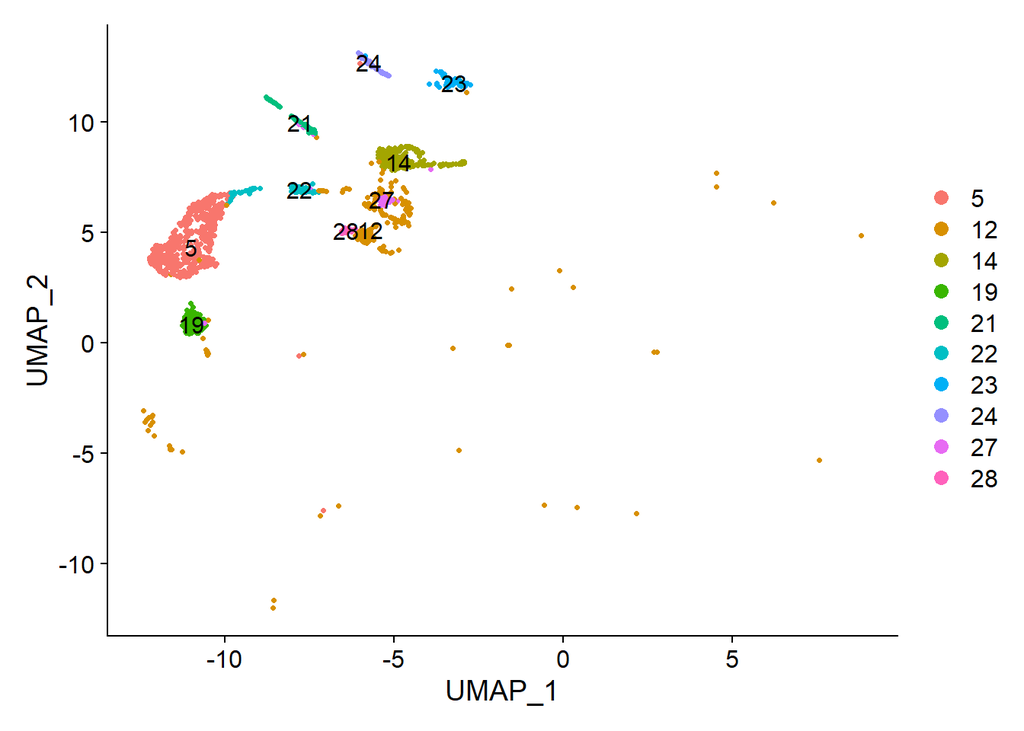

```r
DimPlot(N2234_4_QC, label = TRUE)
```

```r
N2234_4_QC
```

```
## An object of class Seurat
## 54959 features across 1753 samples within 2 assays
## Active assay: RNA (32286 features, 0 variable features)
##  1 other assay present: SCT
##  2 dimensional reductions calculated: PCA, UMAP
```

I am removing the dimensional reductions previously calculated, because it cannot overwrite and will name it umap instead of UMAP, but the default used for visualisation will be UMAP unless other specified. Maybe this causes issues later also during integration?

```r
N2234_4_QC[["PCA"]] <- NULL
N2234_4_QC[["UMAP"]] <- NULL
```

```r
N2234_4_QC
```

```
## An object of class Seurat
## 54959 features across 1753 samples within 2 assays
## Active assay: RNA (32286 features, 0 variable features)
##  1 other assay present: SCT
```

```r
N2234_4_QC <- SCTransform(N2234_4_QC, vst.flavor = "v2", vars.to.regress = "percent.mt")
```

```
## vst.flavor='v2' set, setting model to use fixed slope and exclude poisson genes.
```

```
## Calculating cell attributes from input UMI matrix: log_umi
```

```
## Total Step 1 genes: 19320
```

```
## Total overdispersed genes: 16522
```

```
## Excluding 2798 genes from Step 1 because they are not overdispersed.
```

```
## Variance stabilizing transformation of count matrix of size 19320 by 1753
```

```
## Model formula is y ~ log_umi
```

```
## Get Negative Binomial regression parameters per gene
```

```
## Using 2000 genes, 1753 cells
```

```
## Setting estimate of  37 genes to inf as theta_mm/theta_mle < 1e-3
```

```
## # of step1 poisson genes (variance < mean): 0
```

```
## # of low mean genes (mean < 0.001): 0
```

```
## Total # of Step1 poisson genes (theta=Inf; variance < mean): 37
```

```
## Total # of poisson genes (theta=Inf; variance < mean): 2798
```

```
## Calling offset model for all 2798 poisson genes
```

```
## Found 54 outliers - those will be ignored in fitting/regularization step
```

```
## Ignoring theta inf genes
```

```
## Replacing fit params for 2798 poisson genes by theta=Inf
```

```
## Setting min_variance based on median UMI:  0.04
```

```
## Second step: Get residuals using fitted parameters for 19320 genes
```

```
## Computing corrected count matrix for 19320 genes
```

```
## Wall clock passed: Time difference of 17.50323 secs
```

```
## Determine variable features
```

```
## Place corrected count matrix in counts slot
```

```
## Centering data matrix
```

```
## Set default assay to SCT
```

```r
N2234_4_QC <- RunPCA(N2234_4_QC)
```

```
## PC_ 1
## Positive:  Dclk1, Gas2, Igf1, Lmx1a, Ptgds, Ror1, Lrp2, Cnmd, Dbi, Atp1a1
##     Enpep, Car12, Epyc, Wfdc2, Fut9, Sulf1, Kcnq1, Lum, Lgals1, Kctd8
##     Rbms3, Itpr1, Meis1, S100b, Scg2, Dach2, Vim, Nupr1, Cdo1, Mt3
## Negative:  Nrxn3, Ankfn1, Grxcr1, Myo3a, Ptprq, Myo6, Kcnh7, Smpx, Otof, Ush2a
##     Galnt13, Thsd7b, Rbm24, Ctnnd2, Sema5b, Tnc, Dscaml1, Strip2, Gabrb3, Tmem178b
##     Adgrv1, Frmd4b, Cep85l, Loxhd1, Srrm4, Pcdh15, Dpp6, Fstl4, Fry, Dytn
## PC_ 2
## Positive:  Sgcz, Itga8, Clu, Spock1, Tecta, Mia, Cdh4, Trpm3, Syt1, Robo2
##     Tectb, Thrb, Zfp804b, Eya1, Tmem117, Sdk1, Epyc, Isl1, Rabgap1l, Hunk
##     Pcdh11x, Bcl2, Frmd3, Slit2, Tox, Celf2, Zdhhc14, Tnfrsf19, Ebf1, Adgrg2
## Negative:  Otor, Car3, Col1a2, Grid2, Col3a1, Col25a1, Igfbp2, Ptgds, Vim, Cald1
##     Apod, Apoe, Cytl1, Prkg1, Crym, Iqgap2, Maf, Dclk1, Cp, Dlc1
##     Ccnd2, Pou3f4, Mdga2, Scg2, Nell1, Dct, Anks1b, Lrp1b, Serpinf1, Lmx1a
## PC_ 3
## Positive:  Otor, Car3, Ptn, Col3a1, Crym, Igfbp2, Apod, Sparcl1, Tectb, Ecrg4
##     Cytl1, Dcn, Cald1, Mdga2, Col2a1, Col25a1, Maf, Dct, Kctd12, Serpinf1
##     Grid2, Pou3f4, Cp, Dlc1, Gm44593, Lrp1b, Ccnd2, Col1a1, Igfbp4, Cped1
## Negative:  Nkain2, Lmx1a, Pde4b, Galnt7, Dclk1, Tanc2, Ltbp1, Rasgef1b, Car12, Map1b
##     Lum, Scg2, Adgra3, Nupr1, Epyc, Cdo1, Sgcd, Fut9, Gas2, Aqp5
##     Otol1, Cnmd, Itgbl1, Lgr5, Itm2b, Slc26a4, Stard13, Itga9, Arl4c, Fgf9
## PC_ 4
## Positive:  Ppp2r2b, Nckap5, Erbb4, Tenm4, Nrcam, Dock5, Slitrk6, Igfbp3, Cyp26b1, S100a1
##     Dgkb, Lockd, Rflnb, Cep41, Sox2, Lsamp, Rorb, Sorbs2, Ptprk, Ptprz1
##     Kcnb2, Ephb1, Kif26b, Dpf3, Frmd4a, Dync1i1, Kcnh8, Mast4, Sipa1l1, Socs2
## Negative:  Epyc, Ecrg4, Mia, Clu, Calb1, Lum, Crabp1, Nebl, Sgcz, Cdh4
##     Itm2a, Slit2, Col1a2, Galnt7, Cdkn1c, Adgrg2, Slit3, Srgap1, Tnfrsf19, Mdk
##     Tns3, Col9a1, Tmem132c, Vim, Scg2, Tmem117, Rspo2, Itm2b, Pcolce2, Col2a1
## PC_ 5
## Positive:  Vim, Scg2, Nupr1, Col1a2, Lum, Pgm5, Lgr5, Pde4b, Rasgef1b, Tanc2
##     Sgcd, Itgbl1, Otol1, Nckap5, Nkain2, Map1b, Fxyd6, Aqp5, Adgra3, Dgkb
##     Prss23, Fbln2, Irx3, Itm2b, Igfbp3, Prkg1, Cyp26b1, Dock5, Slitrk6, Otogl
## Negative:  Lrp2, Slc12a2, Kctd8, Meis1, Sulf1, Cacnb2, Dach1, Meis2, Cacna2d1, Enpep
##     Frem1, Ptgds, Ccdc3, Rnf152, Fam20a, Cited1, Atp1b2, Znrf2, Oc90, Kcne1
##     Rspo3, Lrpap1, Ank3, Ehd3, Itpr1, Atp13a5, Dnase1, Mt3, Stac, Aldh1a2
```

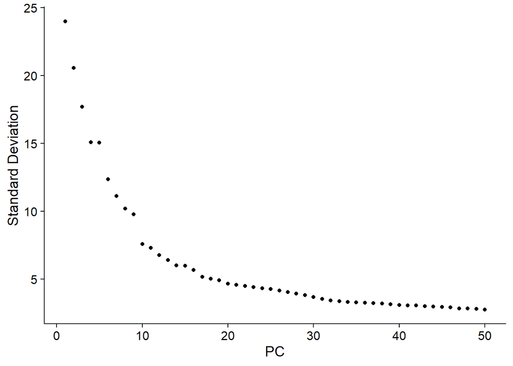

```r
ElbowPlot(N2234_4_QC, ndims = 50)
```

```r
N2234_4_QC <- FindNeighbors(N2234_4_QC, dims = 1:30)
N2234_4_QC <- FindClusters(N2234_4_QC)
```

```
## Modularity Optimizer version 1.3.0 by Ludo Waltman and Nees Jan van Eck
##
## Number of nodes: 1753
## Number of edges: 50211
##
## Running Louvain algorithm...
## Maximum modularity in 10 random starts: 0.8920
## Number of communities: 16
## Elapsed time: 0 seconds
```

```r
N2234_4_QC <- RunUMAP(N2234_4_QC, dims = 1:30)
```

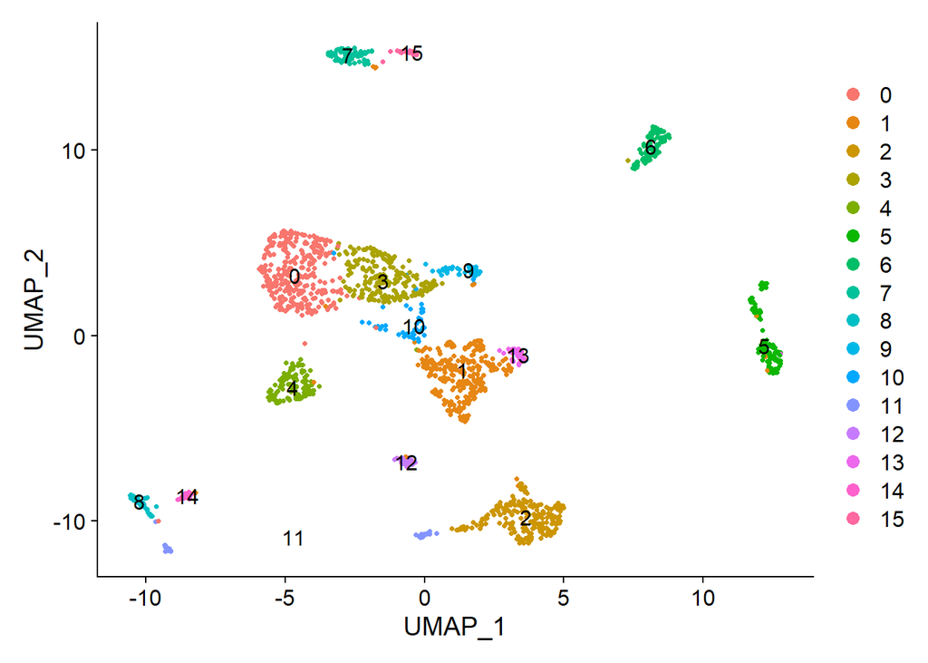

```r
DimPlot(N2234_4_QC, label = TRUE)
```

```r
DefaultAssay(N2234_4_QC) <- "SCT"
```

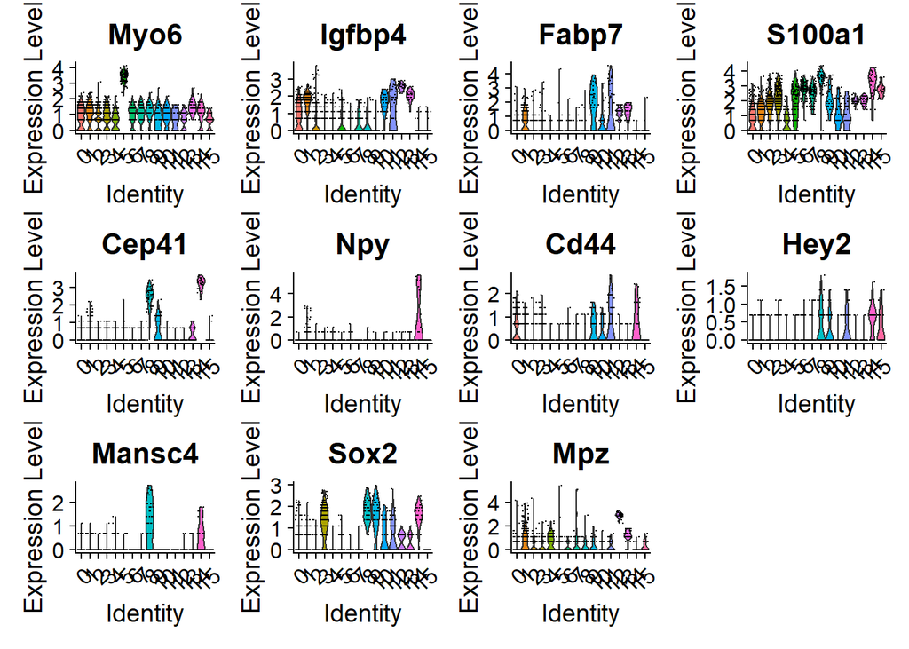

```r
VlnPlot(N2234_4_QC, features = c("Myo6", "Igfbp4", "Fabp7", "S100a1", "Cep41", "Npy", "Cd44", "Hey2", "Mansc4", "Sox2", "Mpz"))
```

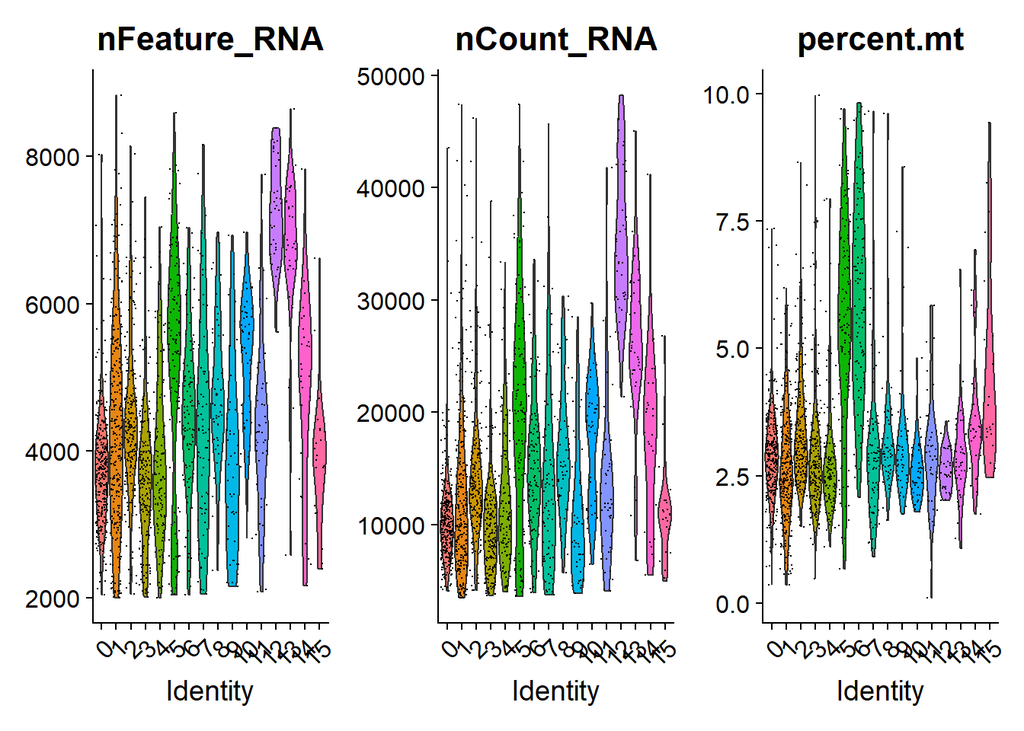

```r
VlnPlot(N2234_4_QC, features = c("nFeature_RNA", "nCount_RNA", "percent.mt"), ncol = 3)
```

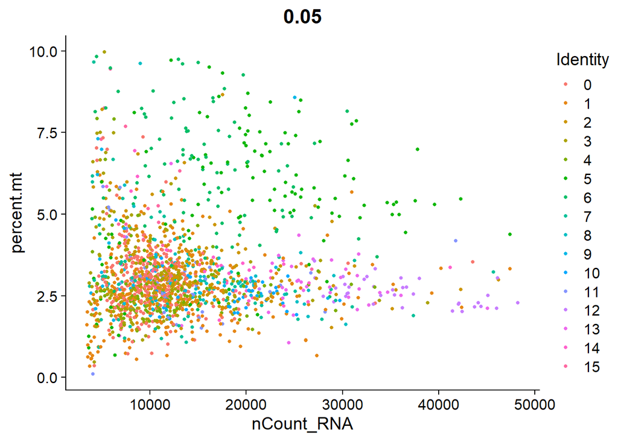

```r
FeatureScatter(N2234_4_QC, feature1 = "nCount_RNA", feature2 = "percent.mt")
```

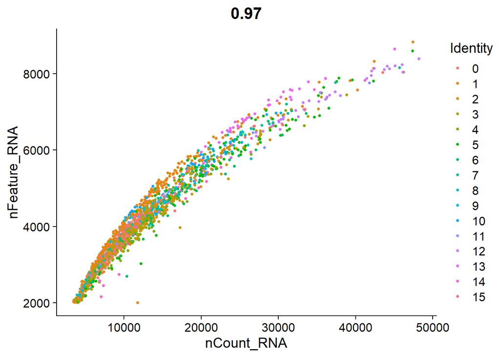

```r
FeatureScatter(N2234_4_QC, feature1 = "nCount_RNA", feature2 = "nFeature_RNA")
```

Looks good, lets save RDS

```r
saveRDS(N2234_4_QC, file = "N2234_4_QC.RDS")
```